# 資料取用說明

本目錄說明如何透過 DeepFlow 「資料源連線管理」，進行各種資料來源的資料取用

## 資料源連線管理設定

1. 點選 DeepFlow 頁面右上角的使用者帳號後，點選「設定」--> 「資料源連線管理」

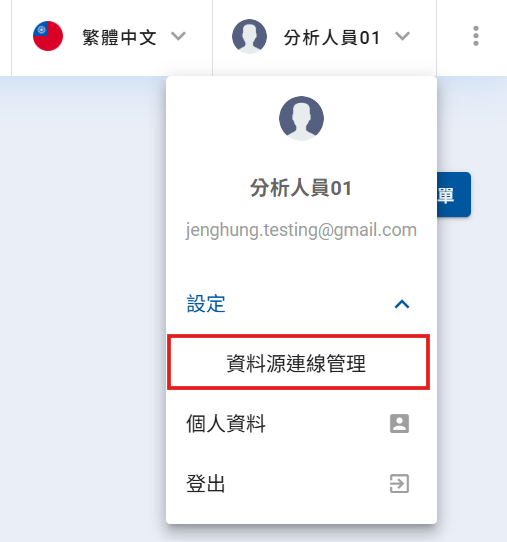

2. 此功能提供一個安全的密碼儲存區(key vault)，可儲存 **「個人」** 擁有的資料源連線設定

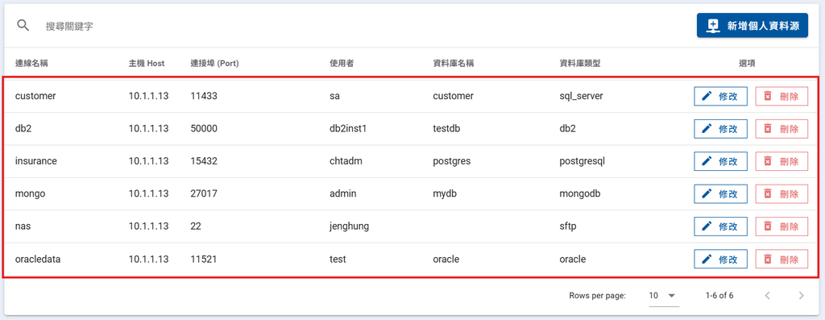

## 新增一筆個人資料源

1. 點選 「新增個人資料源」後，選擇資料源類型

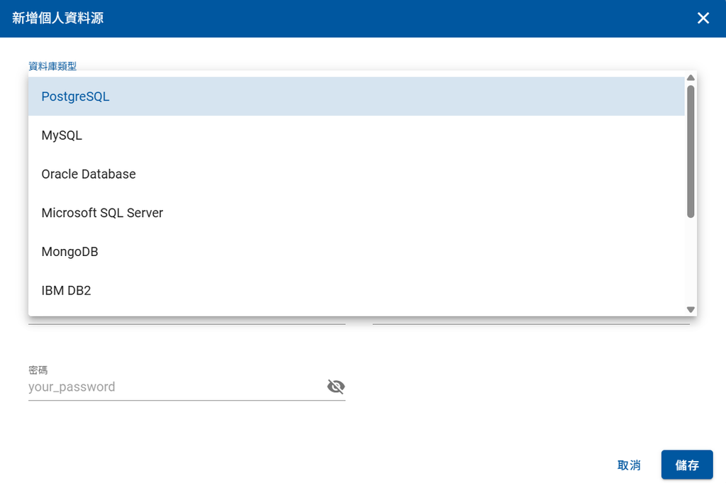

2. 給予此資料源一個自訂的 **「連線名稱」**，做為識別

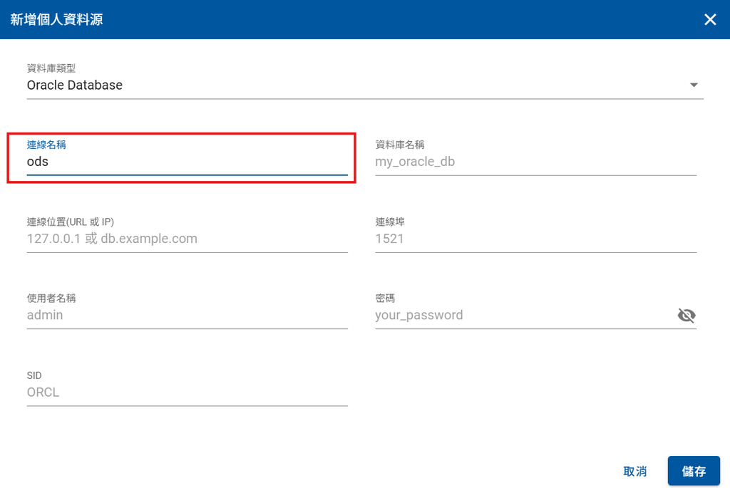

3. 依照畫面填入連線資訊，並按「儲存」完成新增

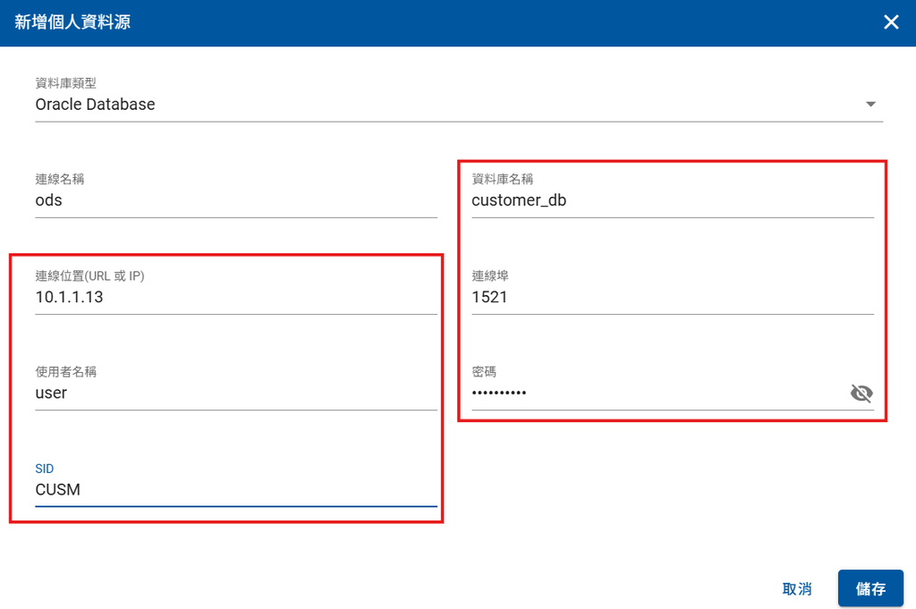

4. 個人資料源連線列表會多增加一筆設定

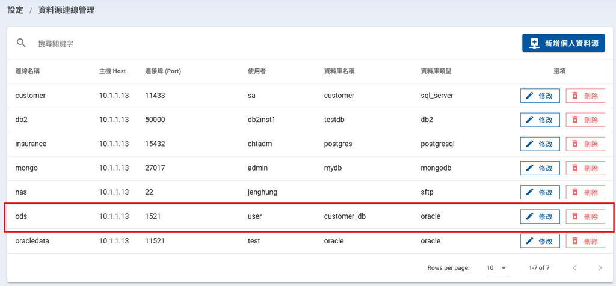

## 如何在程式碼當中取得資料源連線資訊

DeepFlow 開啟的開發環境、部署的排程或 API，皆可使用 SDK 取得指定資料源的連線資訊至變數，避免將連線資訊 hard code 在檔案或程式碼當中

```python
from vdclient_magic.core.utils import get_datasource_config
```

```python
datasource_config = get_datasource_config("ods")
```

```python
datasource_config
```

```
{'database': 'customer_db',
 'datasource': 'ods',
 'full_name': 'Oracle Database',
 'host': '10.1.1.13',
 'password': '1qqsqslwje',
 'port': '1521',
 'sid': 'CUSM',
 'type': 'oracle',
 'username': 'user'}
```

## 資料取用或資料庫操作說明

### [方法二] 使用 DeepFlow 提供的 vdclient SDK

請參考

- 2_vdclient_rdb_connection.ipynb
- 3_vdclient_sftp_mongo.ipynb

### [方法三] 在 Jupyterlab 內，可使用 DeepFlow 提供的 vdclient magic

請參考

- 4_vdclient_magic.ipynb

### [方法四] DeepFlow 提供的 vdclient magic，也可使用 sdk 方式在 .py 上執行

請參考

- 5_vdclient_magic_sdk.ipynb